# Estimates of Carrying Capacity with Quantile Random Forest Models

Kevin See, Mike Ackerman, and Richie Carmichael

April 01, 2020

<sup>1</sup> Biomark, Inc.

# 1 Introduction

## 1.1 QRF Model

We developed a quantile random forest (QRF) model with paired fish and habitat data from a number of sites around the Columbia River Basin (Table 1.1). We developed separate QRF models for each species, using the haitat covariates shown in Table 1.2.

Table 1.1: Number of sites with fish/habtiat data that went into QRF model.

| Watershed | Chinook | Steelhead |
| --- | --- | --- |
| Asotin | 0 | 12 |
| Entiat | 54 | 71 |
| John Day | 36 | 106 |
| Lemhi | 17 | 48 |
| Minam | 15 | 15 |
| Upper Grande Ronde | 88 | 120 |
| Total | 210 | 372 |

Table 1.2: Selected habitat covariates for QRF model.

| Metric | Name | MetricCategory | DescriptiveText |
| --- | --- | --- | --- |
| CU_Freq | Channel Unit Frequency | ChannelUnit | Number of channel units per 100 meters. |
| SlowWater_Pct | Slow Water Percent | ChannelUnit | Percent of wetted area identified asSlow Water/Pool channel units. |
| Sin_CL | Sinuosity Via Centerline | Complexity | Ratio of the wetted centerline length (Site Length Wetted) and the straight line distance between the start and end points of the wetted centerline. Generated by the River Bathymetry Toolkit (RBT) |
| WetBraid | Wetted Channel Braidedness | Complexity | Ratio of the total length of the wetted mainstem channel plus side channels and the length of the mainstem channel. |
| WetSC_Pct | Wetted Side Channel Percent By Area | Complexity | Ratio of the total area of side channel unit areas (both small and large) divided by the total area of channel unit polygons. |
| FishCovSome | Fish Cover: Some Cover | Cover | Percent of wetted area with some form of fish cover |
| FishCovSome | Fish Cover: Some Cover | Cover | Percent of wetted area with some form of fish cover |
| UcutLgth_Pct | Percent Undercut by Length | Cover | The percent of the wetted streambank length that is undercut. |
| DistPrin1 | Disturbance Class PCA 1 | Land Classification | Disturbance Classification PCA 1 Score |
| Q | Discharge | Size | The sum of station discharge across all stations. Station discharge is calculated as depth x velocity x station increment for all stations except first and last. Station discharge for first and last s… |
| WetWdth_Int | Wetted Width Integrated | Size | Average width of the wetted polygon for a site. |
| SubEstGrvl | Substrate Est: Coarse and Fine Gravel | Substrate | Percent of coarse and fine gravel (2-64 mm) within the wetted site area. |
| SubEstGrvl | Substrate Est: Coarse and Fine Gravel | Substrate | Percent of coarse and fine gravel (2-64 mm) within the wetted site area. |
| avg_aug_temp | Avg. August Temperature | Temperature | Average predicted daily August temperature from NorWest, averaged across the years 2002-2011. |
| LWFreq_Wet | Large Wood Frequency: Wetted | Wood | Number of large wood pieces per 100 meters within the wetted channel. |
| LWVol_Wet | Large Wood Volume: Wetted | Wood | Total volume of large wood pieces within the wetted channel, scaled by site length. |

The relative importance of the habitat covariates are shown in Figure 1.1.

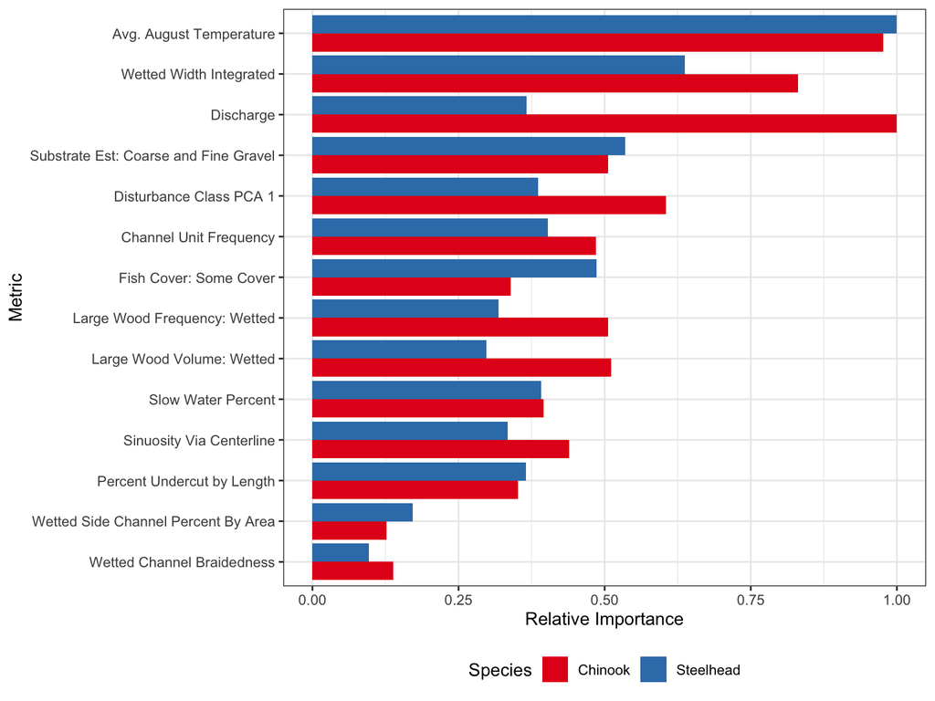

Figure 1.1: Relative importance of each habitat covariate, colored by species.

Partial dependence plots show the marginal effect of each covariate by displaying the predicted capacity as that covariate changes, assuming all the other covariates remain fixed at their average values. The partial dependence plots are shown for Chinook (Figure 1.2) and steelhead (Figure 1.3).

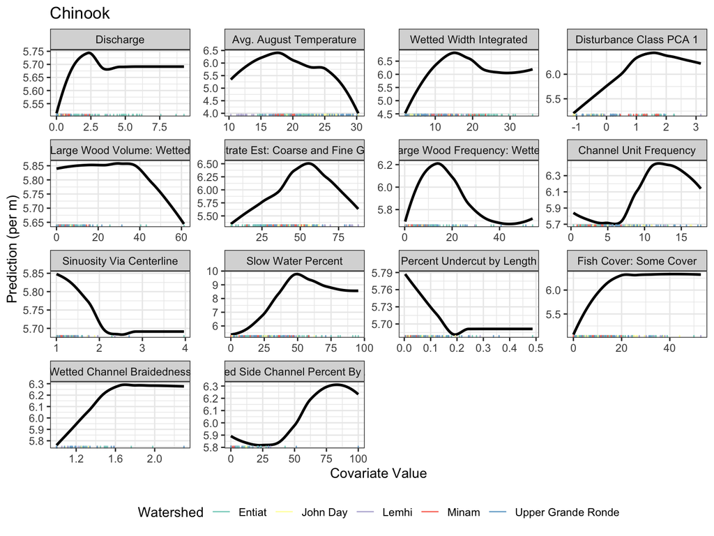

Figure 1.2: Partial dependence plots for Chinook QRF model.

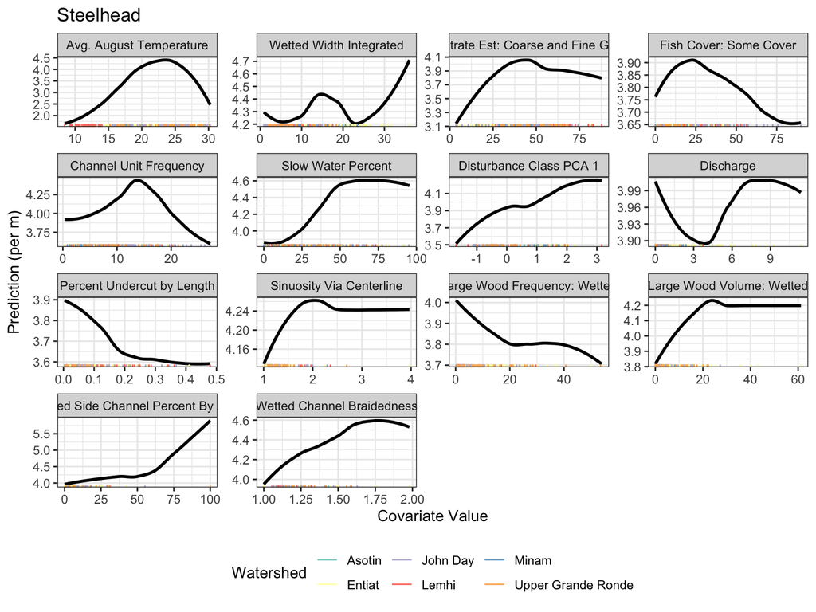

Figure 1.3: Partial dependence plots for steelhead QRF model.

From this QRF model, we made capacity predictions at every CHaMP site, after averaging the habitat metrics across years for sites visited more than once. We then tied each CHaMP site to a 200 m reach on a stream network with various attributes, and used those attributes to extrapolate capacity to every 200 m reach on that network.

# 2 Methods

## 2.1 Geomorphic Reaches

We took our QRF extrapolation estimates at each 200 m reach, and determined which reaches fell into each geomorphic reach within each watershed. Then we examined the distribution of capacity estimates within each reach, and the average capacity for each reach.

## 2.2 Capacity at MRA sites

We used the QRF model to predict capacity at MRA sites that were sampled with DASH in 2018. We used the predicted 90th quantile as a proxy for carrying capacity.

# 3 Results

## 3.1 Geomorphic Reaches

The distribution of capacity predictions within each geomorphic reach is shown in Figures 3.1 and 3.2. Figures 3.3, 3.4 and 3.5 are maps depicting the average capacity within each geomorphic reach.

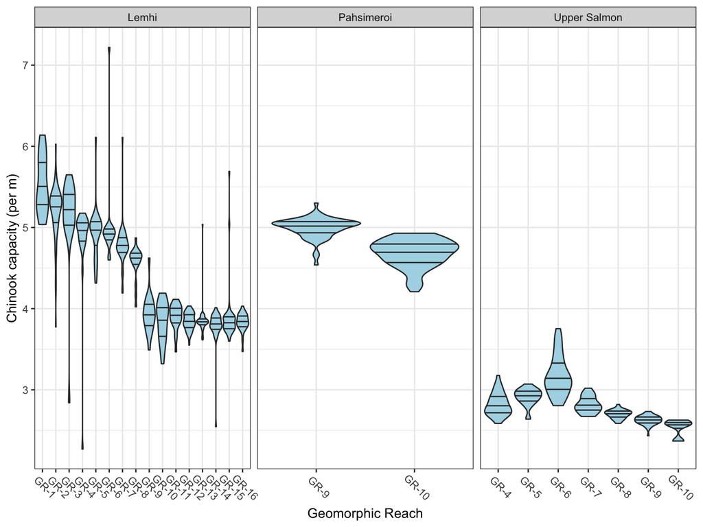

Figure 3.1: Violin plots showing the distribution of Chinook capacity estimates for 200 m reaches within each geomorphic reach in each watershed.

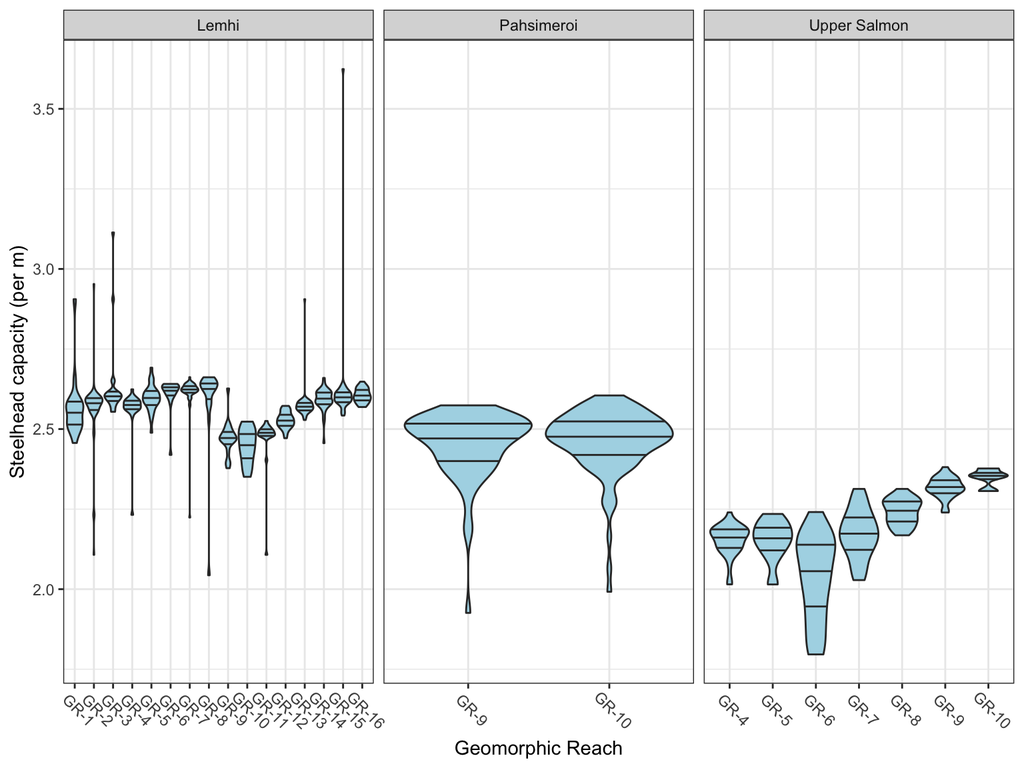

Figure 3.2: Violin plots showing the distribution of steelhead capacity estimates for 200 m reaches within each geomorphic reach in each watershed.

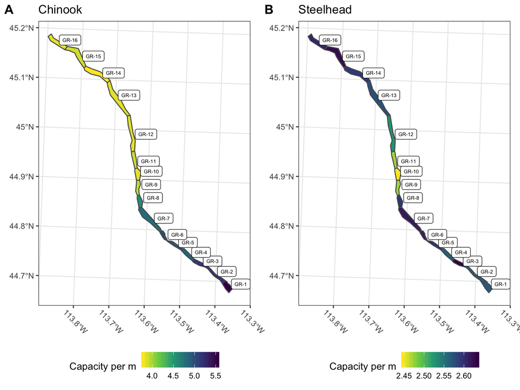

Figure 3.3: Geomorphic reaches in the Lemhi colored by average capacity (fish per m). Note different scales for each species.

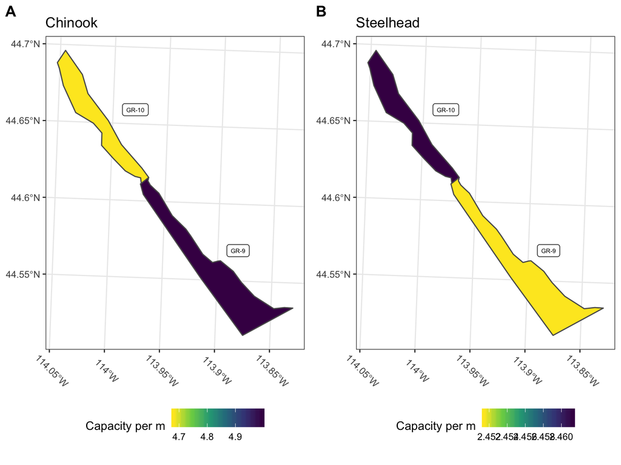

Figure 3.4: Geomorphic reaches in the Pahsimeroi colored by average capacity (fish per m). Note different scales for each species.

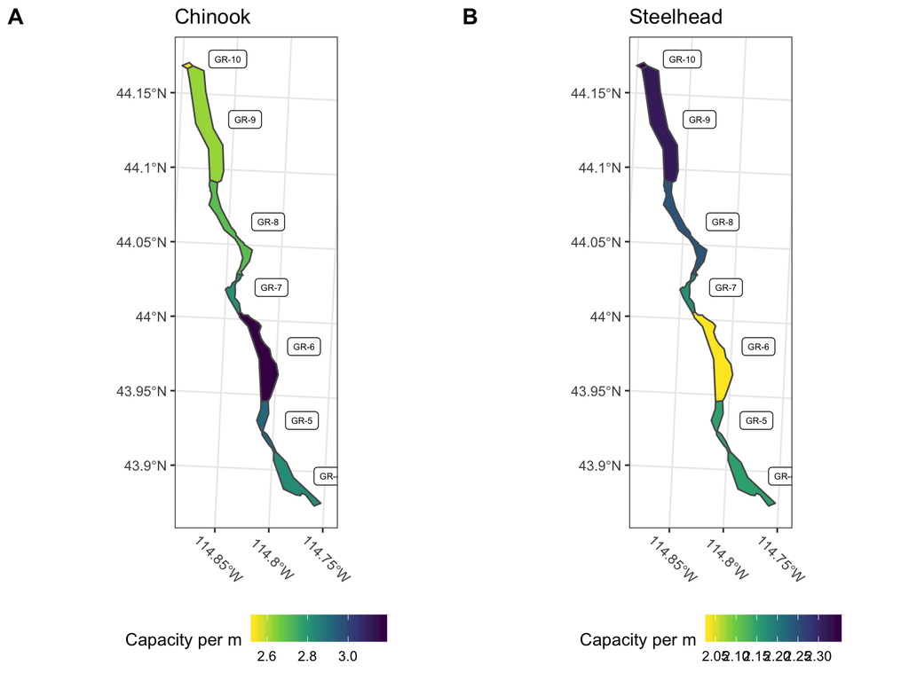

Figure 3.5: Geomorphic reaches in the upper Salmon colored by average capacity (fish per m). Note different scales for each species.

## 3.2 Capacity at MRA sites

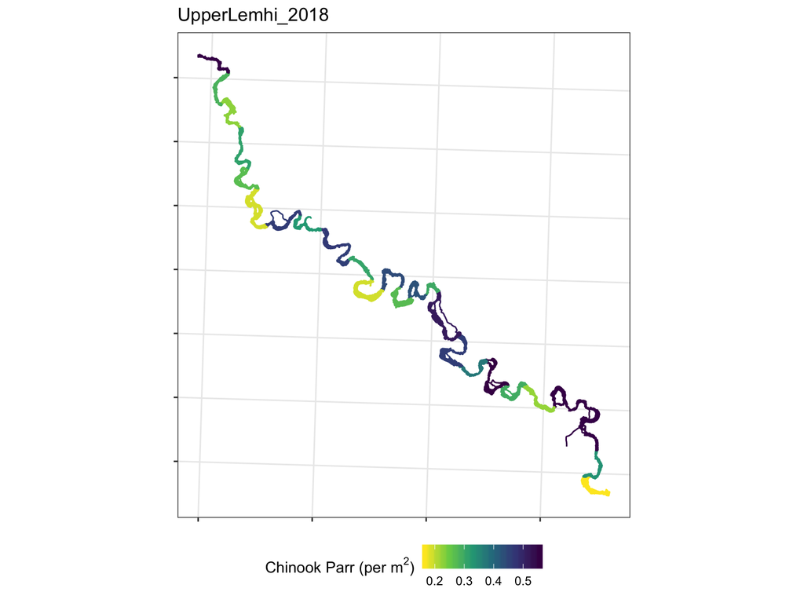

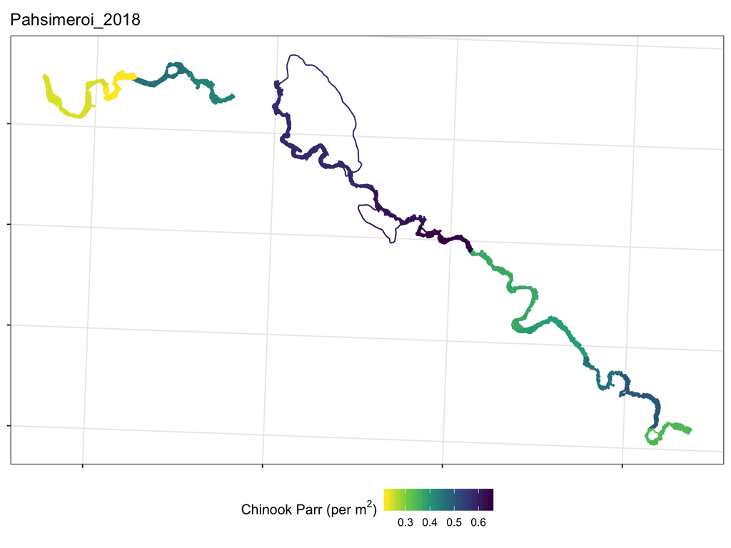

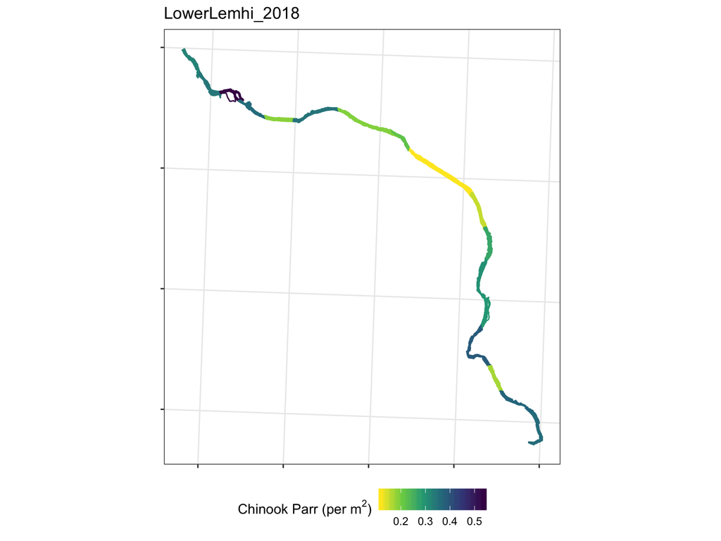

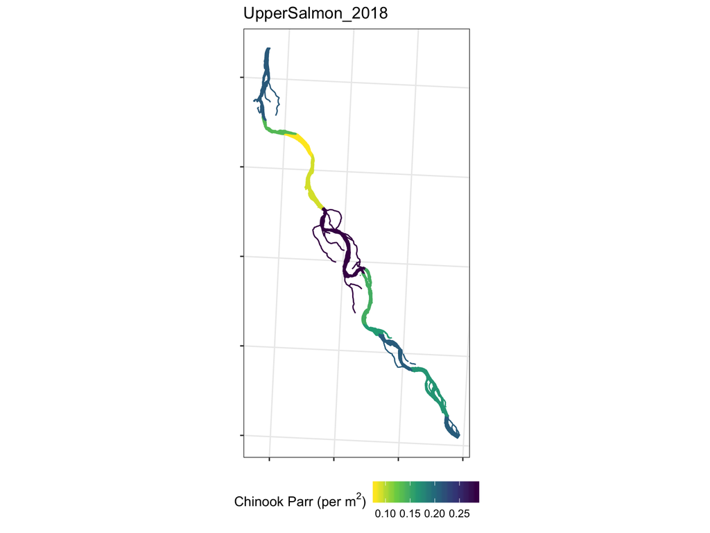